# Case Study 01

Anna Frowein

November 3, 2016

## Introduction

We reviewed the provided Gross Domestic Product data provided to compare Income Groupings from the educational data set to GDP ranking and GDP dollars in the GDP data set. In order to fully understand the data we cleaned the data sets, merge them together, and created our own data points for analysis.  
This document will provide the steps in which these actives were performed and their results. We will also be answering the following questions:

```
-How many Countries matched between the two data sets?

-When the merged data is sorted, which country was 13th in the sorted data?

-Provide a Plot of GDP for each country, color coded by Income Group.

-How many Lower middle income countries are actually among the best nations when comparing GDP?
```

## R Setup

The program used in the clean up and analysis of the data was R. The following code provides the setup required for the R Session, including setting working directory (please be sure to change to your working directory) and the required libraries to be loaded.

```r
#First code line is commented out and is for installing the required packages if they are not already installed.  If this code is need uncomment this segment
#install.packages(c("repmis","RCurl","ggplot2","gtools","brew","data.table","datasets","dplyr","stats")
library(repmis)
library(RCurl)
library(brew)
library(data.table)
library(dplyr)
library(stats)
library(datasets)
library(ggplot2)
library(gtools)
#Set the working directory and check it to make sure it is right.
getwd() #This is check to see where the "default" working directory is set
```

```
## [1] "C:/Users/anna_frowein/Documents/SMU/Doing Data Science/CaseStudy1"
```

```r
#In the next segment be sure to set for your Working directory path
setwd("C:/Users/anna_frowein/Documents/SMU/Doing Data Science/CaseStudy1")
getwd() #this is to double check that the directory is properly set
```

```
## [1] "C:/Users/anna_frowein/Documents/SMU/Doing Data Science/CaseStudy1"
```

## Downloading and Cleaning the Data Sets

### Downloading the Data Sets

We were provided with two data sets from the internet. The follow R code provides the means to download the data from the websites they are on to your local computer. The list.files function is included in order to double check that the files are present in your working directory. The R code also provides the required code to read the raw data into R and some functions to provide reviews of the data at this point.

```r
#Downloand the raw data sets into the working directory from the websites and check to see that they are in the working directory
siteGDP<-"https://d396qusza40orc.cloudfront.net/getdata%2Fdata%2FGDP.csv"
siteEDU<-"https://d396qusza40orc.cloudfront.net/getdata%2Fdata%2FEDSTATS_Country.csv"
download.file(siteGDP,destfile="./GDP_Raw.csv")
download.file(siteEDU,destfile="./Education_Raw.csv")
list.files()
```

```
## [1] "AFroweinCaseStudy01.html"  "AFroweinCaseStudy01.Rmd"
## [3] "AFroweinCaseStudy01_files" "Education_Clean.csv"
## [5] "Education_Raw.csv"         "GDP_Clean.csv"
## [7] "GDP_Raw.csv"               "WorkingCodeAll.R"
```

```r
#Load data files into R and review their headers and data
GDP_Raw<-read.csv("./GDP_Raw.csv",header=TRUE)
Education_Raw<-read.csv("./Education_Raw.csv",header=TRUE)
head(GDP_Raw)
```

```
##     X Gross.domestic.product.2012 X.1           X.2          X.3 X.4 X.5
## 1                                  NA                                 NA
## 2                                  NA               (millions of      NA
## 3                         Ranking  NA       Economy  US dollars)      NA
## 4                                  NA                                 NA
## 5 USA                           1  NA United States  16,244,600       NA
## 6 CHN                           2  NA         China   8,227,103       NA
##   X.6 X.7 X.8
## 1  NA  NA  NA
## 2  NA  NA  NA
## 3  NA  NA  NA
## 4  NA  NA  NA
## 5  NA  NA  NA
## 6  NA  NA  NA
```

```r
head(Education_Raw)
```

```
##   CountryCode                    Long.Name         Income.Group
## 1         ABW                        Aruba High income: nonOECD
## 2         ADO      Principality of Andorra High income: nonOECD
## 3         AFG Islamic State of Afghanistan           Low income
## 4         AGO  People's Republic of Angola  Lower middle income
## 5         ALB          Republic of Albania  Upper middle income
## 6         ARE         United Arab Emirates High income: nonOECD
##                       Region Lending.category Other.groups  Currency.Unit
## 1  Latin America & Caribbean                                Aruban florin
## 2      Europe & Central Asia                                         Euro
## 3                 South Asia              IDA         HIPC Afghan afghani
## 4         Sub-Saharan Africa              IDA              Angolan kwanza
## 5      Europe & Central Asia             IBRD                Albanian lek
## 6 Middle East & North Africa                                U.A.E. dirham
##   Latest.population.census  Latest.household.survey
```

[output cut: 83 more lines]

```r
summary(GDP_Raw)
```

```
##        X            Gross.domestic.product.2012   X.1
##         :102                      :135          Mode:logical
##  ABW    :  1   178                :  2          NA's:330
##  ADO    :  1   .. Not available.  :  1
##  AFG    :  1   1                  :  1
##  AGO    :  1   10                 :  1
##  ALB    :  1   100                :  1
##  (Other):223   (Other)            :189
##                           X.2               X.3      X.4
##                             :101              :101    :324
##    East Asia & Pacific      :  1   ..         : 23   a:  1
##    Euro area                :  1    767       :  2   b:  1
##    Europe & Central Asia    :  1    1,008     :  1   c:  1
##    Latin America & Caribbean:  1    1,129     :  1   d:  1
##    Lower middle income      :  1    1,129,598 :  1   e:  1
##  (Other)                    :224   (Other)    :201   f:  1
##    X.5            X.6            X.7            X.8
##  Mode:logical   Mode:logical   Mode:logical   Mode:logical
##  NA's:330       NA's:330       NA's:330       NA's:330
##
##
##
##
##
```

```r
View(Education_Raw)
View(GDP_Raw)
```

### Cleaning the Data

```r
#Cleaning the data files
#copying files for manipulation to ensure raw data stays entact
file.copy("./Education_Raw.csv","./Education_Clean.csv")
```

```
## [1] FALSE
```

```r
file.copy("./GDP_Raw.csv","./GDP_Clean.csv")
```

```
## [1] FALSE
```

```r
#Create Clean Data files removing unwated columns and rows as well as applying common headers for merging
GDP_Clean<-read.csv("./GDP_Clean.csv",header=TRUE)
GDP_Clean<-GDP_Clean[-c(1:4,195,220,222,236:330),-c(3,6:10)]
setnames(GDP_Clean,1,"shortcode")
setnames(GDP_Clean,2,"GDPRanking")
setnames(GDP_Clean,3,"Economy")
setnames(GDP_Clean,4, "GDPinUSMill")
GDP_Clean$GDPinUSMill <- as.numeric(gsub("[^[:digit:]]",0, GDP_Clean$GDPinUSMill))
GDP_Clean$GDPRanking <- as.numeric(gsub("[^[:digit:]]",0, GDP_Clean$GDPRanking))
Education_Clean<-read.csv("./Education_Clean.csv",header=TRUE)
Education_Clean<-Education_Clean[,-c(4:31)]
setnames(Education_Clean,"CountryCode","shortcode")
View(Education_Clean)
View(GDP_Clean)
```

## Creation of Merged Data Set

Once the data clean up was done the data sets were merged into a new data set. At this point we are able to see that there are 224 matches based on the Short Country code between the two data sets being reviewed.

```r
#merge data sets by the shortcode columns
MergeGDP<-merge(Education_Clean,GDP_Clean,by="shortcode")
#How many matches are in the dataset, a row count answer this as the merge function omits non matched countries.
nrow(MergeGDP)
```

```
## [1] 224
```

## Sort Merged Data by GDP Ranking

Next the merged data set was sorted into a new data set by the the GDP ranking, in order to obtain the desired result of the United States being last in this data set, a descending sort was performed. The following R code provides the required coding to sort the data and to find which Country is now listed 13th within the data. The country is Isle of Man. There is also code to view the overall data set sorted.

```r
#sort by GDP with USA being at the end, and give the Country listed 13th.
SortedMergeGDP<-MergeGDP[order(MergeGDP$GDPRanking,na.last = FALSE,decreasing = TRUE),]
View(SortedMergeGDP)
SortedMergeGDP[13,"Long.Name"]
```

```
## [1] Isle of Man
## 234 Levels: American Samoa Antigua and Barbuda ... World
```

## Average GDP Rankings

```r
aggregate(MergeGDP$GDPRanking, list(MergeGDP$Income.Group), mean, trim=0, na.rm=TRUE)
```

```
##                Group.1         x
## 1                            NaN
## 2 High income: nonOECD  91.91304
## 3    High income: OECD  32.96667
## 4           Low income 133.72973
## 5  Lower middle income 107.70370
## 6  Upper middle income  92.13333
```

## Plot of GDP

Next we plotted the GDP Dollars for each of the countries, with color coding based on Income Group.

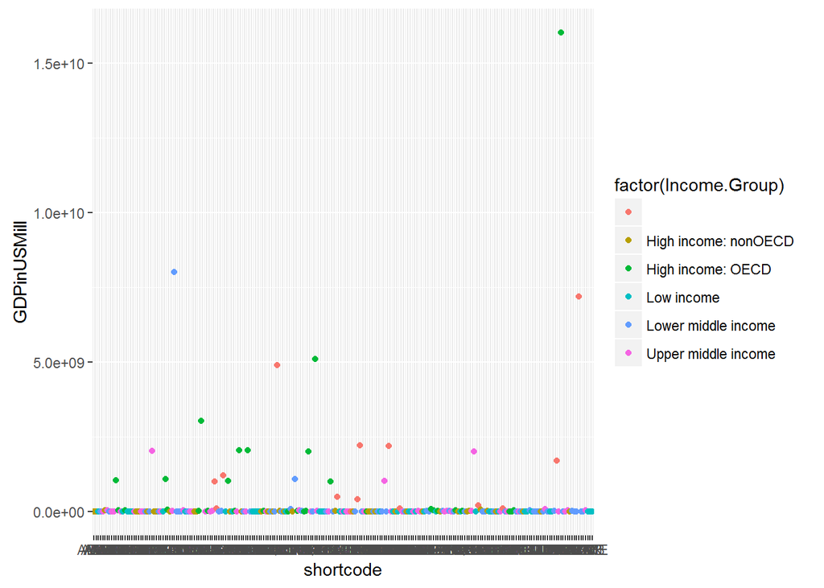

```r
PlotGDP<-ggplot(MergeGDP,aes(shortcode,GDPinUSMill))
PlotGDP+geom_point(aes(color=factor(Income.Group)))
```

## Quantile Groups by GDP Ranking

The last analysis performed was a quantile analysis, in which five(5) separate quantiles were created based on the GDP Ranking of the countries. This was added to the Merged Data set and a new data set was created. The following R code will provide the required code to create and review the quantiles created. We also found that 5 countries in the Lower middle income group are apart of the top ranking countries.

```r
Quant<-MergeGDP[quantcut(MergeGDP$GDPRanking,q=5,na.rm=TRUE),]
QuantMergeGDP<-mutate(MergeGDP,Quantile=quantcut(MergeGDP$GDPRanking,q=5,na.rm=TRUE))
View(QuantMergeGDP)
QITable<-table(QuantMergeGDP$Quantile,QuantMergeGDP$Income.Group)
QITable
```

```
##
##                  High income: nonOECD High income: OECD Low income
##   [1,38.6]     0                    4                18          0
##   (38.6,76.2]  0                    5                10          1
##   (76.2,114]   0                    8                 1          9
##   (114,152]    0                    4                 1         16
##   (152,190]    0                    2                 0         11
##
##               Lower middle income Upper middle income
##   [1,38.6]                      5                  11
##   (38.6,76.2]                  13                   9
##   (76.2,114]                   11                   8
##   (114,152]                     9                   8
##   (152,190]                    16                   9
```

```r
QITable["[1,38.6]","Lower middle income"]
```

```
## [1] 5
```

## Conclusion

Based on the analysis performed, what really stuck out was that Countries that participated in the Organisation for Economic Co-operation and Development (OECD) generally had a higher ranking than other countries and were all apart of a “High income” group. This is an observational study so no causality can truly be placed on effect of Ranking that being OECD has, however, based on this data if some under-developed countries could participate in the OECD then the over GDP could increase.